# Uncertainty

### Introduction

Estimates have uncertainty. Here we look at the mean and its sampling distribution for a continuous and a binary scaled variables. We calculate the mean and its standard error using the normal approximation and using the bootstrap.

### Installing the packages and loading the data

To illustrate the technique, we are going to use data from eBeer.

```r
# install.packages(c("memisc", "foreign", "data.table", "dplyr","VGAM"))
# options("scipen"=100, "digits"=4)

# install.packages(c("memisc", "foreign", "data.table", "dplyr","VGAM"))

library(data.table)
library(foreign)
library(memisc)
```

Set the working directory to a folder where you will you put class related stuff.

```r
setwd("C:/Users/gknox/Dropbox/Customer Analytics/R notebooks/RFM & logistic")
```

Set the seed so that random draws are the same for everyone. I create a folder within the working directory for data called … data.

```r
set.seed(19103)

ebeer <- data.frame(as.data.set(spss.system.file('./data/E-Beer.sav')))
```

```
## File character set is 'UTF-8'.
```

```
## Converting character set to the local 'iso8859-1'.
```

```r
#ebeer<- data.frame(as.data.set(spss.system.file(file.choose())))
```

Let’s take a look at the variable monetary value. This is the average amount per transaction spent by customer. I’m going to refer to it as the monetary value. Here’s its histogram.

```r
dim(ebeer)
```

```
## [1] 9964   11
```

```r
head(ebeer)
```

|  | acctnum | gender | R | F | M | firstpur | age_class | single | student | mailing | respmail |
| --- | --- | --- | --- | --- | --- | --- | --- | --- | --- | --- | --- |
| 1 | 10001 | M | 30 | 10 | 35.7 | 50 | 36-40 | yes | yes | 1 | 0 |
| 2 | 10005 | F | 16 | 1 | 149.0 | 16 | 18-25 | no | yes | 1 | 0 |
| 3 | 10010 | F | 12 | 1 | 123.0 | 12 | 18-25 | yes | no | 1 | 0 |
| 4 | 10011 | F | 6 | 2 | 147.0 | 8 | 18-25 | yes | yes | 1 | 0 |
| 5 | 10014 | M | 6 | 3 | 96.0 | 18 | 18-25 | no | yes | 1 | 1 |
| 6 | 10020 | F | 12 | 2 | 150.5 | 14 | 18-25 | yes | yes | 1 | 0 |

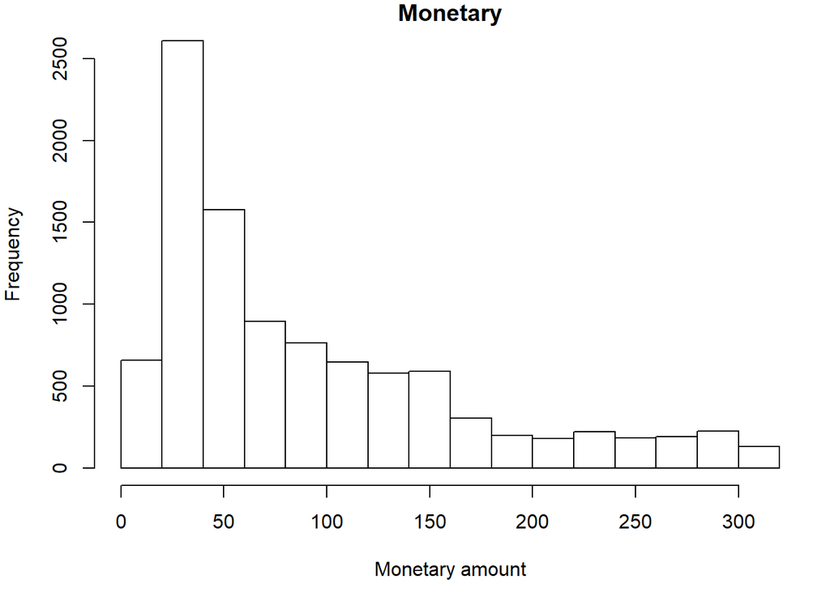

```r
par(mai=c(.9,.8,.2,.2))
hist(ebeer$M, main="Monetary", xlab="Monetary amount")
```

How many customers are in our data? What is the mean monetary value, its variance, and standard error?

Remember the sample mean is:
$$\bar{x} = \frac{1}{n} \sum_{i=1}^{n} x_i$$
And the variance of it is:
$$var(\bar{x}) = var \left( \frac{1}{n} \sum_{i=1}^{n} x_i \right) = \frac{1}{n^2} \sum_{i=1}^{n} var(x_i) = \frac{\sigma^2}{n}$$
where $\sigma^2 = \frac{1}{n-1}\sum_{i=1}^{n} (x_i - \bar{x})^2$ is the variance. The variance goes inside the parentheses because we assume each customer is independent. And the standard error is $se(\bar{x}) = \frac{\sigma}{\sqrt{n}}$. (I’m ignoring finite sample adjustment here.)

```r
nrow(ebeer)
```

```
## [1] 9964
```

```r
xbar <- mean(ebeer$M)
xbv <- var(ebeer$M)/nrow(ebeer)
xbse <-  sqrt(xbv)

xbar
```

```
## [1] 91.99312
```

```r
xbv
```

```
## [1] 0.5713062
```

```r
xbse
```

```
## [1] 0.755848
```

What is the sampling distribution of the mean? If we were able to get a new sample from the same data-generating process what would it be? According to the central limit theorem, the distribution is normal, $\bar{x} \sim N(\bar{x}, var(\bar{x}))$. This distribution below:

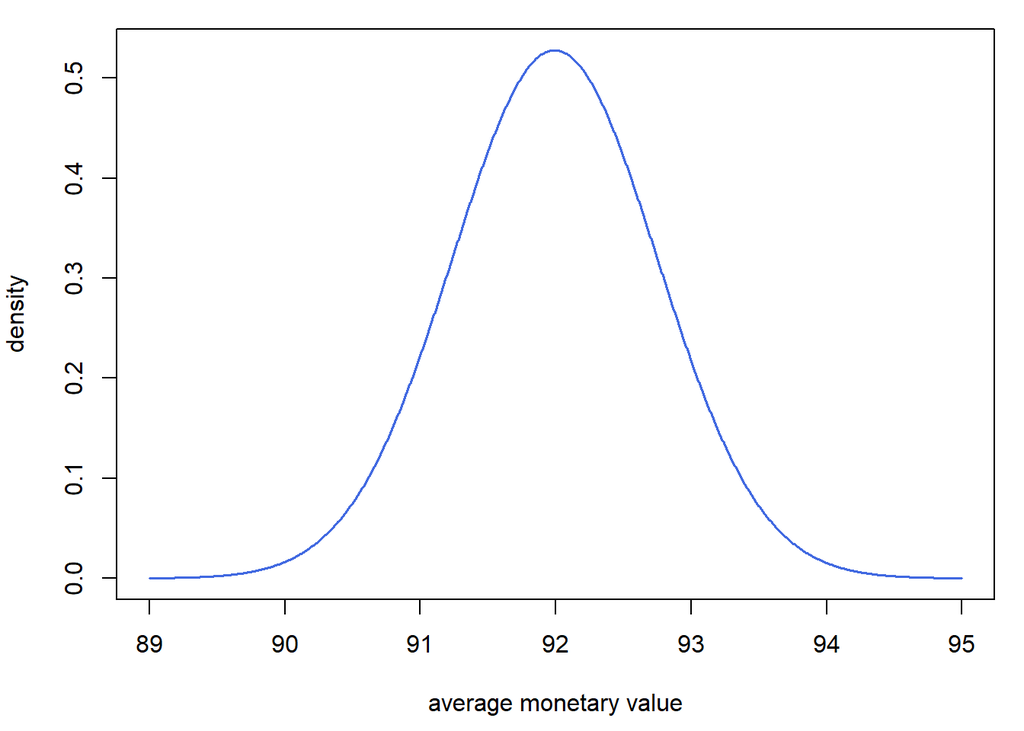

```r
xx <- seq(89,95,length=1000)

par(mai=c(.9,.8,.2,.2))
plot(xx, dnorm(xx, xbar, xbse), type="l", col="royalblue", lwd=1.5,
     xlab="average monetary value", ylab="density")
```

Another way to compute the distribution is using the bootstrap. The idea is to resample your data *with replacement*, calculating the statistic each time, e.g., $\bar{x}_1, \bar{x}_2, \dots \bar{x}_B$ and using that to calculate the distribution of the statistic.

```r
# nonparametric bootstrap
B <- 10000
mub <- c()
for (b in 1:B){
  samp_b = sample.int(nrow(ebeer), replace=TRUE)
  mub <- c(mub, mean(ebeer$M[samp_b]))
}
sd(mub)
```

```
## [1] 0.7524937
```

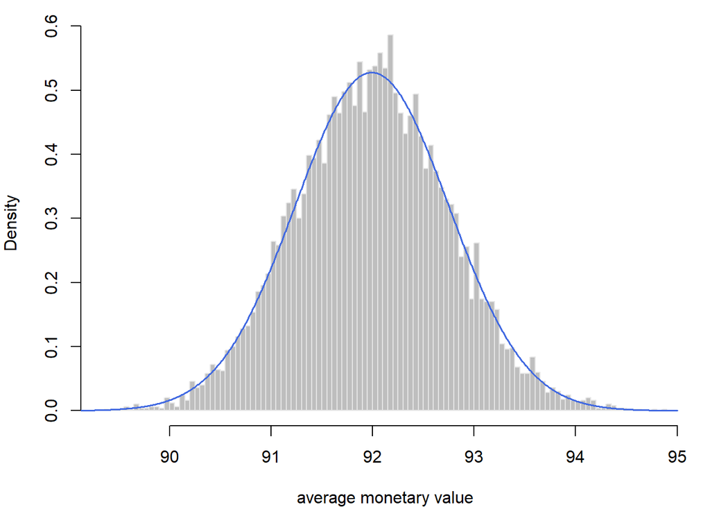

```r
par(mai=c(.8,.8,.2,.2))
hist(mub, main="", xlab="average monetary value", breaks = 100,
     col=8, border="grey90", freq=FALSE)
lines(xx, dnorm(xx, xbar, xbse), col="royalblue", lwd=1.5)
```

Compare the standard errors from the normal approximation and the bootstrap sample. You can create a 95% confidence interval around the mean using the standard error from the bootstrap.

```r
mean(mub) + c(-1,1)*2*sd(mub)
```

```
## [1] 90.49215 93.50212
```

The bootstrapped sampled with replacement. In the last sample, you can see person 1 was sampled twice, person 2 also twice, etc.:

```r
sort(samp_b)[1:10]
```

```
##  [1] 1 1 2 2 3 3 4 5 5 5
```

### Help for assignment 1

Now let’s take a look at a binary variable, marketing response.

```r
table(ebeer$respmail)
```

```
##
##    0    1
## 4336  616
```

```r
mean(ebeer$respmail)
```

```
## [1] NA
```

You may get a problem here because only about half of the people in the data set received a mail. For those missing a mail, the response will be NA, which creates an error. So let’s remove those people, focusing on the subset of people who received a mailing.

```r
ebeer<-ebeer[!is.na(ebeer$respmail),]

n<-nrow(ebeer)
```

Make sure response is numeric, 1 if responded and 0 if not, and not a factor variable with two labels. The function as.numeric gets used a lot.

```r
ebeer$respmail<-as.numeric(ebeer$respmail)

table(ebeer$respmail)
```

```
##
##    0    1
## 4336  616
```

In the case that x is binary, the variance is $\sigma^2 = \hat{p}(1-\hat{p})$.